# MTDT_Function_ClassifyR

Andy Wang, Andy Tran & Jamie Mickaill

01/02/2022

# Multi Tier Decision Tree for Clinical Diagnostics

This program aims to use a sequential, machine learning approach to build a forest of multi-level clinical diagnostic trees with multi-omics data. This will allow for comparison of the cost and accuracy of different sequences of predictive models. With this information, we hope to enable better informed decisions of diagnostic processes.

At each node of the tree, a machine learning model is used to establish the sample specific accuracy of health outcome predictions for a single layer of the multi-omics data (e.g. how accurate is the prediction for a single individual based on their histology data?). If the prediction can not be made with sufficient accuracy, the individual will progress to the next level where an alternative model and layer of the omics data will be used. Currently each layer is analysed seperately, such that we have analysis of multiple single-omics datasets (ensemble learning to be implemented ?)

(Andy Wang) There are differences in terms of how these predictors variables could be obtained, how invasive they could be acquired, and how much they cost. The goal here is to find an optimal testing sequence with the different input models that we have, balancing it with the tier model error rates (TSER), the difficulty and differences in their unit cost.

```r
#User Inputs

###############################################################################

#Choose the MultiAssayExperiment Object for performing classification
MultiAssayExperiment = bioheart_mae


#Properties for weighting
#(E.g. # of individuals retained or total cost of all tests performed at a given tier)
properties = c("TSA.retained", "Cost.Total")

#To be updated:
#Currently weighting function is incorrect: (scaled(P1) * W1) + (scaled(P1) * W2) + (scaled(PN) * WN)

#Weights for properties
#(E.g. evaluation of best tier defined by relative error * -0.5 + relative cost * -0.5 )
weights = c(0.5,-0.5)

#List of tier names
#For melanoma example: longRNA has too many features, we just want a single iTRAQ****
tierList = c( "Metabolomics"  ,    "Proteomics"  , "sampleInfo" )

#Sample specific error cutoffs
#(E.g. x | if the sample specific error of cross validated prediction is > x, the sample will 'progress' to the next tier. Lower cutoff = higher retention generally)
# ssercutoffList= list(c(0.4, 0.4, 0.4),c(0.6, 0.6, 0.6)) # -> For multi-threshold analysis
ssercutoffLists= list(c(0.4, 0.4, 0.4))

#Tier costs (e.g. price of performing test for an individual), Clinical also last index
tierUnitCosts = c(100, 500, 1000)

#Which tier to fix as first in Tree? (If any)
# e.g. fixedTier = "Clinical"
# fixedTier = "clinical"
fixedTier = "sampleInfo"

#Minimum size of Tier
minTierSize = 50


#name of classifier/classes column in dataset
classes = "CAD"

#Performance type (e.g. Sample Error)
performanceType = "Sample Error"


##Cross validation parameters (could create a list for each experiment)
crossValParams = CrossValParams(
    samplesSplits = "Permute k-Fold",
    permutations = 5,
    percentTest = 25,
    folds = 5,
    leave = 1,
    tuneMode = "none",
    parallelParams = bpparam()
)



##Data transformation parameters
# transformParams = TransformParams(transform, characteristics = DataFrame(), intermediate = character(0), ...)
transformParamsList = c(NULL,NULL,NULL,NULL)



##Feature selection parameters
# selectParams = SelectParams(featureSelection, characteristics = DataFrame(), minPresence = 1, intermediate = character(0), subsetToSelections = TRUE, tuneParams = list(nFeatures = seq(10, 100, 10), performanceType = "Balanced Error"), ...)
selectParamsList = c(SelectParams(),SelectParams(),SelectParams(),SelectParams() )


##Training Parameters -> Insert classifier here
# To do: make this easier for the user by creating a funciton which will return the selectParamsList based on a simple classifier name, e.g. "SVM" will return SelectParams(SVMtrainInterface, kernel = "linear")?
#TrainParams = TrainParams(classifier, characteristics = DataFrame(), intermediate = character(0), getFeatures = NULL, ...)
trainParamsList = c(TrainParams(SVMtrainInterface, kernel = "linear", tuneParams = list(cost = c(0.01, 0.1, 1, 10))),TrainParams(randomForestTrainInterface),TrainParams(),TrainParams())

##Prediction Parameters -> Insert classifier here
# PredictParams(predictor, characteristics = DataFrame(), intermediate = character(0), ...)
predictParamsList = c(PredictParams(SVMpredictInterface),PredictParams(randomForestPredictInterface),PredictParams(),PredictParams())

##Modelling params List
modellingParams = list()

for(model in 1:length(tierList)){
  currModellingParams = ModellingParams(
    balancing = "none",
    transformParams  = NULL,
    selectParams = selectParamsList[[model]],
    trainParams = trainParamsList[[model]],
    predictParams = predictParamsList[[model]],
    doImportance = FALSE
)

  modellingParams = c(modellingParams,currModellingParams)
}


#describing the characteristics of the classification used
# characteristics = S4Vectors::DataFrame()
#to do: make a list and test out some non-null values
characteristics = NULL

seed=1
verbose=1

###############################################################################
```

## Main Code

```
## harmonizing input:
##   removing 1980 sampleMap rows not in names(experiments)
```

```
## [1] 0
## [1] "(1) sampleInfo-Proteomics-Metabolomics: <sampleInfo>"
```

```
## You have 2 features and 990 samples and only one data-type.
```

```
## Processing sample set 20.
```

```
## Processing sample set 10.
```

[output not shown]

[output cut: 2187 more lines]

[output not shown]

```
## harmonizing input:
##   removing 251 sampleMap rows not in names(experiments)
```

```
## harmonizing input:
##   removing 251 sampleMap rows not in names(experiments)
## Processing sample set 10.
```

```
## Processing sample set 20.
```

[output not shown]

[output cut: 2748 more lines]

[output not shown]

```
## harmonizing input:
##   removing 64 sampleMap rows not in names(experiments)
```

```
## harmonizing input:
##   removing 64 sampleMap rows not in names(experiments)
```

```
## Processing sample set 10.
```

```
## Processing sample set 20.
```

[output not shown]

[output cut: 2942 more lines]

[output not shown]

```
## You have 2 features and 990 samples and only one data-type.
```

```
## Processing sample set 10.
```

```
## Processing sample set 20.
```

[output not shown]

[output cut: 2181 more lines]

[output not shown]

```
## harmonizing input:
##   removing 253 sampleMap rows not in names(experiments)
```

```
## harmonizing input:
##   removing 253 sampleMap rows not in names(experiments)
```

```
## Processing sample set 10.
```

```
## Processing sample set 20.
```

[output not shown]

[output cut: 2583 more lines]

[output not shown]

```
## harmonizing input:
##   removing 119 sampleMap rows not in names(experiments)
```

```
## harmonizing input:
##   removing 119 sampleMap rows not in names(experiments)
## Processing sample set 20.
```

```
## Processing sample set 10.
```

[output not shown]

[output cut: 2940 more lines]

[output not shown]

## Plots

Accuracy / Cost Plot

```
## [1] "\n"
## [1] "sampleInfo-Proteomics-Metabolomics"
## [1] "\n"
##                             levelName counter tierOrder
## 1 sampleInfo                               NA        NA
## 2  ¦--Retained (sampleInfo)               739         1
## 3  °--To progress (sampleInfo)            251         1
## 4      ¦--Retained (Proteomics)           187         2
## 5      °--To progress (Proteomics)         64         2
## 6          °--Retained (Metabolomics)      64         3
## [1] 0.7464646
## [1] 0.9353535
## [1] 1
## [1] "\n"
## [1] "sampleInfo-Metabolomics-Proteomics"
## [1] "\n"
##                            levelName counter tierOrder
## 1 sampleInfo                              NA        NA
## 2  ¦--Retained (sampleInfo)              737         1
## 3  °--To progress (sampleInfo)           253         1
## 4      ¦--Retained (Metabolomics)        134         2
## 5      °--To progress (Metabolomics)     119         2
## 6          °--Retained (Proteomics)      119         3
## [1] 0.7444444
## [1] 0.879798
## [1] 1
```

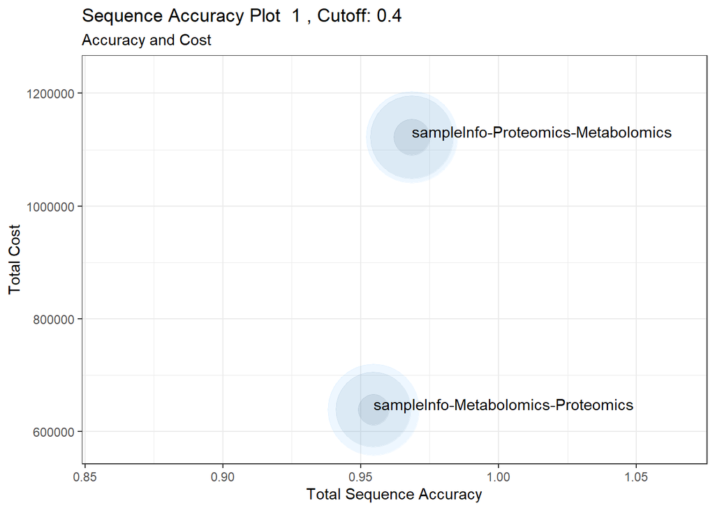

Table

|  | Tier.Sequence | TSA.retained | N.Total | Threshold | Cost.byTier | Cost.Total | Weight |
| --- | --- | --- | --- | --- | --- | --- | --- |
| 1 | sampleInfo-Proteomics-Metabolomics | 0.968484848484849 | 990 | 0.4 | $990000-$125500-$6400 | 1121900 | -5.55111512312578e-17 |
| 2 | sampleInfo-Metabolomics-Proteomics | 0.954545454545455 | 990 | 0.4 | $495000-$25300-$119000 | 639300 | 5.55111512312578e-17 |

Tree Plots & Strata Plots

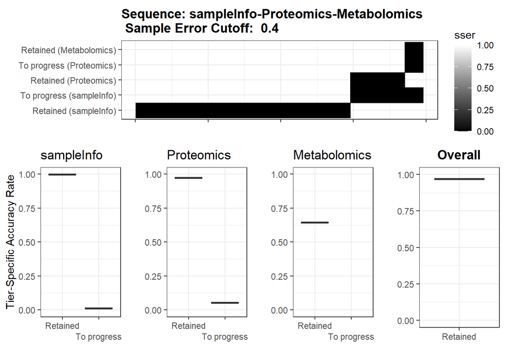

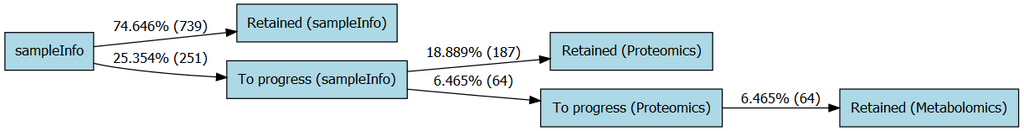

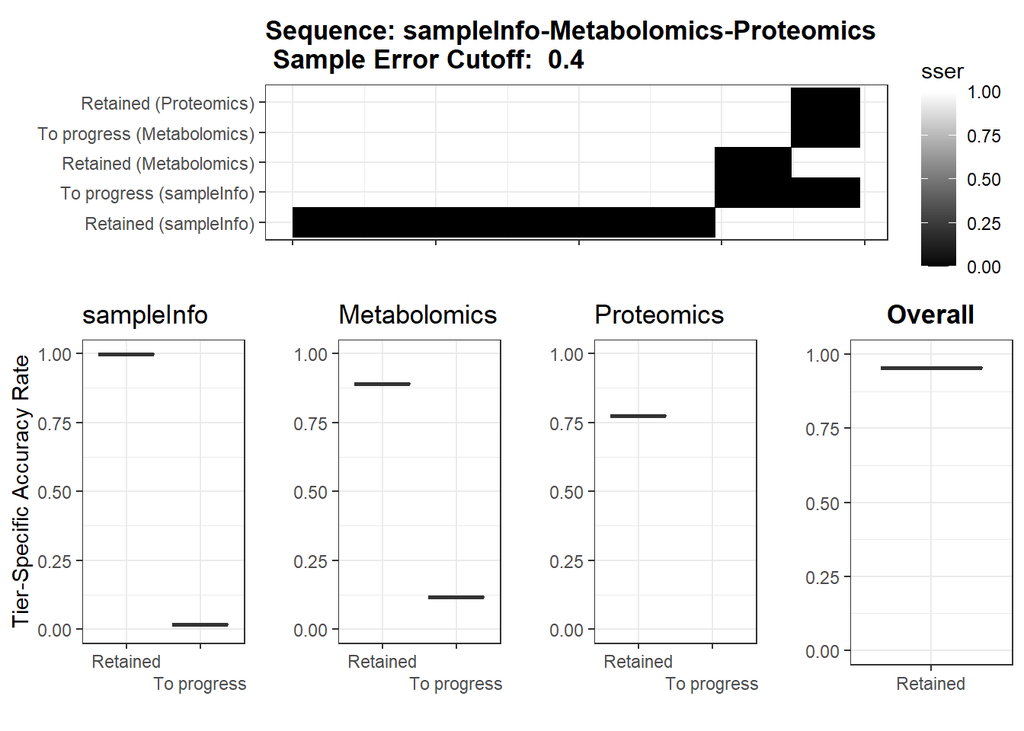

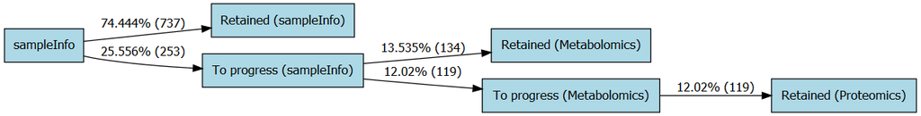